# Math Stat Midterm Take Home

Gabe Mancino

10/16/2017

### Midterm Take Home Portion

# Question 1

Since $F(\cdot)$ satisfies the definition of a continuous CDF, $U\sim UNIF(0,1)$ and $Y\equiv F^{-1}(U)$, then
$$\begin{align*}
P(Y\le t) &=P(F^{-1}(U)\le t)\\
&=P(U\le F(t))\\
&=\int_{0}^{F(t)}1\cdot dy\\
&=F(t)-0\\
&=F(t).\\
\end{align*}$$

Thus $Y\sim F(\cdot)$ by definition.

# Question 2

Define the following PDF of $Y$ as follows:
$$f(y)=\frac{1}{\pi\sqrt{(y-a)(b-y)}}$$
for $y\in[a,b]$ with $a<b$.

## a.

Consider $y\in [2,6]$, then our equation becomes:
$$f(y)=\frac{1}{\pi\sqrt{(y-2)(6-y)}}.$$

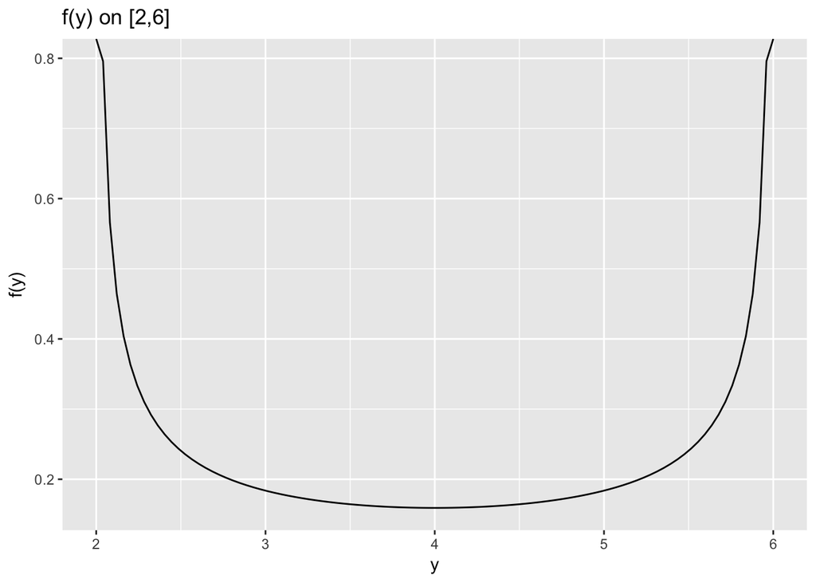

```r
library(ggplot2)
yvals <- seq(2, 6, l = 100)
fy <- function(y) {
  pdfy <- 1/(pi*sqrt((y-2)*(6-y)))
  return(pdfy)
}
yvals <- seq(2, 6, l = 100)
pfy <- fy(yvals)
mydata <- data.frame(yvals, pfy)
ggplot(aes(x = yvals,y = pfy), data = mydata) + geom_line(color = "black") + xlab('y') + ylab('f(y)') + ggtitle('f(y) on [2,6]')
```

## b.

The CDF of $Y$ is defined to be $F(Y)\equiv P(Y\le y)=\int\limits_{-\infty}^{y}f(r)dr$, hence we are looking for the following integral:

$$\int_{a}^{y}\frac{1}{\pi\sqrt{(r-a)(b-r)}}dr.$$

Letting $u=\frac{r-a}{b-a}$ we now have:
$$\int_{0}^{\frac{y-a}{b-a}}\frac{(b-a)du}{\pi\sqrt{(b-a)^2u(1-u)}}=\int_{0}^{\frac{y-a}{b-a}}\frac{du}{\pi\sqrt{u(1-u)}}.$$

Making a second change of variable: $t=\sqrt(u)\Rightarrow t^2=u$, thus $du=2tdt$. Our integral now becomes:

$$\int_{0}^{\sqrt{\frac{y-a}{b-a}}}\frac{2tdt}{\pi\sqrt{t^2(1-t^2)}}=\int_{0}^{\sqrt{\frac{y-a}{b-a}}}\frac{2dt}{\pi \sqrt{1-t^2}}=\frac{2}{\pi}\int_{0}^{\sqrt{\frac{y-a}{b-a}}}\frac{dt}{\sqrt{1-t^2}}$$

Noticing that the last integral has a well known antiderivative, we can conclude:
$$F(y)=\frac{2}{\pi}\arcsin(t)\Big|_0^{\sqrt{\frac{y-a}{b-a}}}=\frac{2}{\pi}\arcsin({\sqrt{\frac{y-a}{b-a}}}).$$

Hence, we can conclude the following:
$$F(y)=
\begin{cases}
0 & y\le a\\
\frac{2}{\pi}\arcsin({\sqrt{\frac{y-a}{b-a}}}) & y\in(a,b).\\
1 & y\ge b\\
\end{cases}$$

## c.

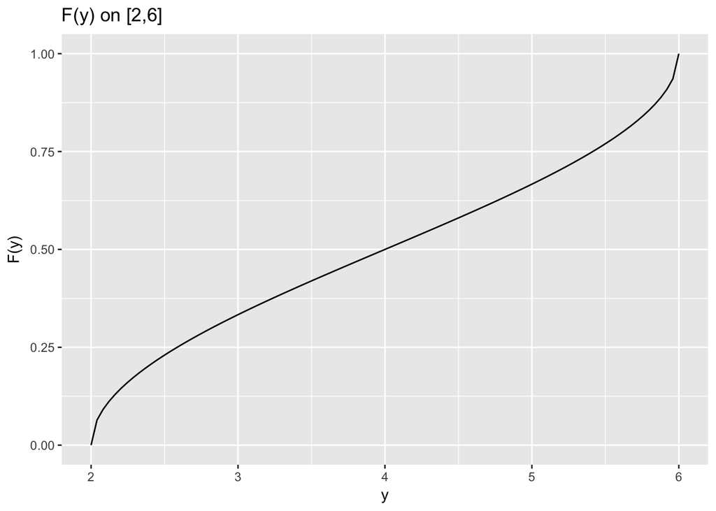

```r
Fy <- function(y, a, b) {
  if (y <= a){
    return(0)}
  if (y >= b){
    return(1)}
  if (y < b & y > a) {
    cdff <- (2/pi)*asin(sqrt((y-a)/(b-a)))
    return(cdff)}
}
yvals <- seq(2, 6, l = 100)
plot.cdff <- sapply(yvals, Fy, a = 2, b = 6)
my.data <- data.frame(yvals, plot.cdff)
ggplot(aes(x = yvals,y = plot.cdff), data = my.data) + geom_line(color = "black") + xlab('y') + ylab('F(y)') + ggtitle('F(y) on [2,6]')
```

## d.

Using b. and letting $a=2$ and $b=5$, we can proceed as follows:
$$P(3\le Y\le 5)=\int_3^5f(y)dy=F(5)-F(3)=\frac{2}{\pi}\arcsin({\sqrt{\frac{5-2}{6-2}}})-\frac{2}{\pi}\arcsin({\sqrt{\frac{3-2}{6-2}}}).$$
Thus we have $F(5) - F(3)$ = 0.3333333.

## e.

Using c. the median of $Y$ appears to be 4.

## f.

```r
Fy.root <- function(y) {
  tosolve <- (2/pi)*asin(sqrt((y-2)/(6-2))) - 0.5
  return(tosolve)
}
uniroot(Fy.root, interval = c(2, 6))
```

```
## $root
## [1] 4
##
## $f.root
## [1] 1.110223e-16
##
## $iter
## [1] 2
##
## $init.it
## [1] NA
##
## $estim.prec
## [1] 6.103516e-05
```

Hence our guess in e. was accurate.

## g.

Consider the following simulations using $U\sim UNI(0,1)$ and $Y=F^{-1}(U)$:

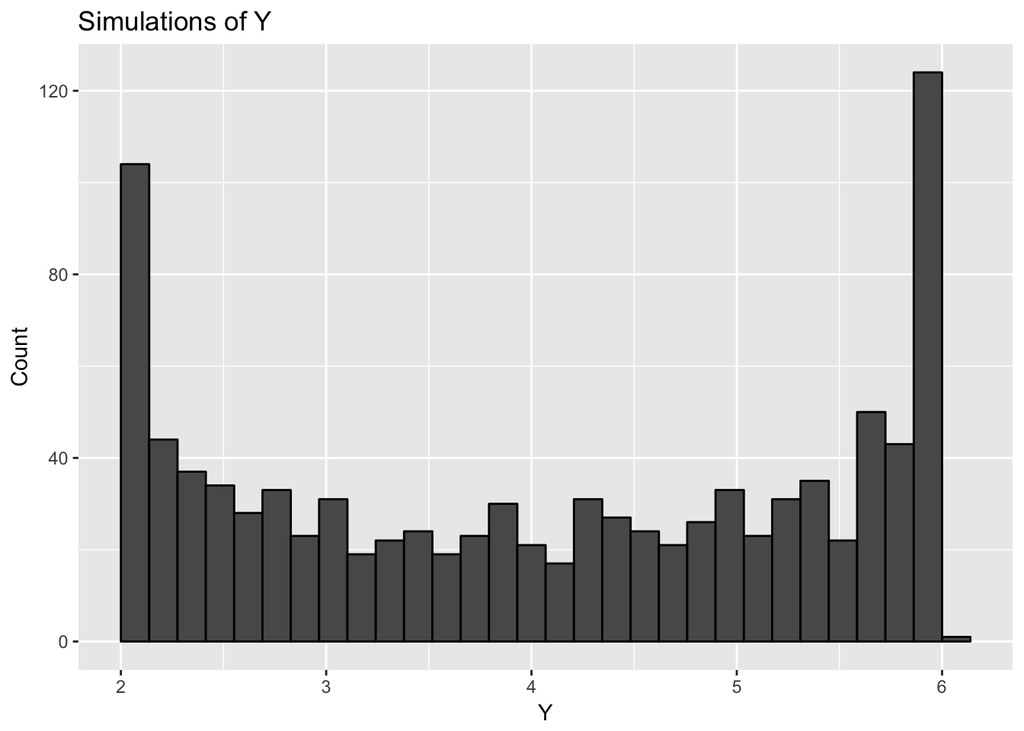

```r
u <- runif(1000, min = 0, max = 1)
y.inv <- function(y) {
  inv <- 4*(sin((pi/2)*y)^2) + 2
  return(inv)
}
many.y.inv <- sapply(u, y.inv)
df <- data.frame(u, many.y.inv)
ggplot(aes(x = many.y.inv), data = df) + geom_histogram(color = "black", bins = 30) + xlab('Y') + ylab('Count') + ggtitle('Simulations of Y')
```

## h.

```r
p.y5 <- sum(many.y.inv <= 5)/1000
p.y3 <- sum(many.y.inv <= 3)/1000
p.5.3 <- p.y5 - p.y3
p.5.3
```

```
## [1] 0.351
```

Thus $\hat{P}(3\le Y\le 5)$ is within 0.0177 of our theoretical probability.

## i.

The median of our simulation is 4.126948 which is within 0.126948 of 4.

## j.

Letting $a=0$ and $b=1$ we can run 1000 simulations of $Y$ as follows:

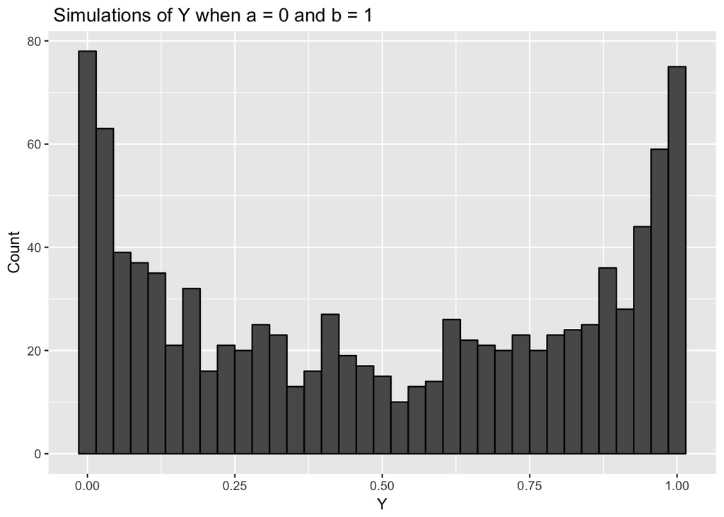

```r
samp <- rbeta(1000, 0.5, 0.5)
df.b <- data.frame(c(1:1000), samp)
ggplot(aes(x = samp), data = df.b) + geom_histogram(color = "black", bins = 35) + xlab('Y') + ylab('Count') + ggtitle(' Simulations of Y when a = 0 and b = 1')
```

# Question 3

## a.

The following is a proof of Markov’s Inequality.

$\textbf{Proof.}$ Let $Y$ be a continuous random variable with finite mean and variance and $g(\cdot)$ is nonnegative. Consider the following set $A\equiv\{y:g(y)\ge k\}$, then $P(g(y)\ge k)=\int_{A}f(y)dy$ by definition. Multipying both sides by $k$ yields $k\cdot P(g(y)\ge k)=k\cdot \int_{A}f(y)dy$, working with the right equation we can push $k$ into the integral since it is a constant to have: $\int_{A}kf(y)dy$. By our construction of $A$, $\int_{A}kf(y)dy\le \int_{A}g(y)f(y)dy\le \int_{\mathbb{R}}g(y)f(y)dy=E[g(Y)]$ because $g(y)$ is nonnegative. Hence moving $k$ around yields
$$P(g(y)\ge k)=\frac{E[g(Y)]}{k}$$
and the proof is complete. QED.

## b.

Markov’s Inequality can be used to prove Tchebysheff’s Inequality as follows:

$\textbf{Proof.}$ Define $g(Y)\equiv \mid Y-\mu\mid=\sqrt{(Y-\mu)^2}$. Then $P(g(Y)\ge k)=P(\sqrt{(Y-\mu)^2}\ge k)=P((Y-\mu)^2\ge k^2)$. Using Markov’s Inequality, $P((Y-\mu)^2\ge k^2)\le \frac{E((Y-\mu)^2)}{^2}=\frac{\sigma ^2}{k^2}$. Letting $a=\frac{k}{\sigma}$ yields
$$P(\sqrt{(Y-\mu)^2}\ge k)=P(\mid Y-\mu \mid \ge k)=P(\mid Y-\mu \mid\ge a\sigma)\le\frac{E((Y-\mu)^2)}{k^2}=\frac{\sigma ^2}{k^2}=\frac{1}{a^2}$$
and hence Tchebysheff’s Inequality has been shown. QED.

## c.

Noticing that Tchebysheff’s Inequality can be rewritten as follows:
$$P(\mid Y-\mu\mid\ge k\sigma)\le \frac{1}{k^2}\Rightarrow 1-P(\mid Y-\sigma\mid<k\sigma)\le \frac{1}{k^2}.$$

Thus for each of the following distributions we will compute $P(\mid Y-\sigma\mid<k\sigma)$ and subtract this value from 1 to compare to the bound in Tchebysheff’s Inequality.

### i.

Let $Y\sim BINOM(50,0.5$), thus the pmf of $Y$ is:
$$P(Y=y)=
\begin{cases}
\binom{50}{y}0.5^y(1-0.5)^{50-y} &y=0,1,2,3,\dots,50\\
0 & otherwise
\end{cases}
.$$
Using what we know about the binomial distribution, $\mu = 50(0.5) =25$ and $\sigma=\sqrt{50(0.5)(0.5)}=3.5355339.$

Hence we can compute $P(\mid Y-\sigma\mid<k\sigma)$ as follows:
$$\begin{align*}
P(\mid Y-\sigma\mid<k\sigma) &= P(-2\sqrt{(0.5)^{2} 50}+50(0.5)<Y<2\sqrt{(0.5)^{2}50}+50(0.5))\\
&=P(17.9289322<Y<32.0710678\\
&=\sum_{y=18}^{32}\binom{50}{y}0.5^y(1-0.5)^{50-y}\\
&=0.9671609.
\end{align*}$$

Thus 1-0.9671609 = 0.0328391 $\le 0.25.$

### ii.

Thus,
$$\begin{align*}
P(\mid Y-\sigma\mid<k\sigma) &= P(-2\sqrt{\frac{1-0.5}{0.5^2}}+\frac{1}{0.5}<Y<2\sqrt{\frac{1-0.5}{0.5^2}}+\frac{1}{0.5})\\
&= P(-0.8284271<Y<4.8284271)\\
&=P(1<Y<4)\\
&=\sum_{y=1}^{4}0.5(0.5)^{y-1}\\
&=0.9375.
\end{align*}$$

Hence 1-0.9375=0.0625$\le0.25$.

### iii.

Let $Y\sim N(2,4)$, then the pdf for $Y$ is:
$$f(y)= \frac{1}{\sqrt{2\pi 4}}e^{-\frac{1}{2}(\frac{y-2}{2})^{2}}$$
for $y\in(-\infty,\infty)$.

From the normal distribution we know $\mu=2$ and $\sigma= 2.$

Thus,
$$\begin{align*}
P(\mid Y-\sigma\mid<k\sigma) &= P(-2(2)+2<Y<2(2)+2)\\
&= P(-2<Y<6)\\
&=\int_{-2}^{6}\frac{1}{\sqrt{2\pi 4}}e^{-\frac{1}{2}(\frac{y-2}{2})^{2}}dy\\
&=0.9545.
\end{align*}$$

Hence 1-0.9545=0.0455 $\le 0.25$.

### iv.

Let $Y\sim GAM(2,4)$, then the pdf for $Y$ is:
$$f(y)=
\begin{cases}
\frac{1}{16}ye^{-\frac{y}{4}} &y\in(0,\infty)\\
0 & otherwise
\end{cases}
.$$

From the gamma distribution we know $\mu=2(4)=8$ and $\sigma=\sqrt{2(4)^2}=\sqrt{32}$.

Thus,
$$\begin{align*}
P(\mid Y-\sigma\mid<k\sigma) &= P(-2\sqrt{32}+8<Y<2\sqrt{32}+8))\\
&= P(-3.3137085<Y<19.3137085)\\
&=\int_{0}^{2\sqrt{32}+8}\frac{1}{16}ye^{-\frac{y}{4}}dy\\
&=0.9534.
\end{align*}$$

Hence 1-0.9534=0.0466$\le 0.25$.

### v.

Let $Y\sim BETA(2,2)$ then the pdf for $Y$ is:
$$f(y)=
\begin{cases}
6y(1-y) &y\in[0,1]\\
0 &otherwise
\end{cases}
.$$

Using what we know about the beta distribution, $\mu=\frac{2}{2+2}=0.5$ and $\sigma=\sqrt{\frac{2(2)}{(2+2)^2(2+2+1)}}=0.2236068.$

Thus,
$$\begin{align*}
P(\mid Y-\sigma\mid<k\sigma) &= P(-2\sqrt{\frac{2(2)}{(2+2)^2(2+2+1)}} + 0.5<Y<2\sqrt{\frac{2(2)}{(2+2)^2(2+2+1)}}+0.5)\\
&= P(0.0527864<Y< 0.9472136)\\
&=\int_{0.0527864}^{0.9472136}6y(1-y)dy\\
&=0.9839.
\end{align*}$$

Hence 1-0.9839=0.0161$\le 0.25$.

## d.

In general, the actual probabilities computed do not come that close to our bound of 0.25. The closest of such was obtained in ii.